# Lab 1

# Training a Model on the Data

- To create this model we’ll use the rpart package. “rpart” stands for recursive partitioning
- rpart function automatically determines that the most important predictor is the variable “alcohol”.
- The root split between <10.85 and >=10.85 as shown below.
- Nodes with an * are terminal or leaf nodes

```r
library(rpart)
m.rpart <- rpart(quality ~ ., data=wine_train)
summary(m.rpart)
```

```
## Call:
## rpart(formula = quality ~ ., data = wine_train)
##   n= 3750
##
##           CP nsplit rel error    xerror       xstd
## 1 0.15501053      0 1.0000000 1.0004214 0.02446470
## 2 0.05098911      1 0.8449895 0.8480225 0.02340002
## 3 0.02796998      2 0.7940004 0.8037796 0.02268364
## 4 0.01970128      3 0.7660304 0.7851223 0.02199063
## 5 0.01265926      4 0.7463291 0.7646581 0.02118232
## 6 0.01007193      5 0.7336698 0.7551127 0.02106882
## 7 0.01000000      6 0.7235979 0.7475517 0.02094537
##
## Variable importance
##              alcohol              density     volatile.acidity
##                   34                   21                   15
##            chlorides total.sulfur.dioxide  free.sulfur.dioxide
##                   11                    7                    6
##       residual.sugar            sulphates          citric.acid
##                    3                    1                    1
##
## Node number 1: 3750 observations,    complexity param=0.1550105
##   mean=5.870933, MSE=0.7854751
##   left son=2 (2372 obs) right son=3 (1378 obs)
##   Primary splits:
##       alcohol              < 10.85    to the left,  improve=0.15501050, (0 missing)
##       density              < 0.992035 to the right, improve=0.10915940, (0 missing)
##       chlorides            < 0.0395   to the right, improve=0.07682258, (0 missing)
##       total.sulfur.dioxide < 158.5    to the right, improve=0.04089663, (0 missing)
##       citric.acid          < 0.235    to the left,  improve=0.03636458, (0 missing)
##   Surrogate splits:
##       density              < 0.991995 to the right, agree=0.869, adj=0.644, (0 split)
##       chlorides            < 0.0375   to the right, agree=0.757, adj=0.339, (0 split)
##       total.sulfur.dioxide < 103.5    to the right, agree=0.690, adj=0.155, (0 split)
##       residual.sugar       < 5.375    to the right, agree=0.667, adj=0.094, (0 split)
##       sulphates            < 0.345    to the right, agree=0.647, adj=0.038, (0 split)
##
## Node number 2: 2372 observations,    complexity param=0.05098911
##   mean=5.604975, MSE=0.5981709
##   left son=4 (1611 obs) right son=5 (761 obs)
```

[output cut: 76 more lines]

```
##       residual.sugar       < 0.975    to the left,  improve=0.03061714, (0 missing)
##       fixed.acidity        < 7.35     to the right, improve=0.02978501, (0 missing)
##       sulphates            < 0.575    to the left,  improve=0.02165970, (0 missing)
##   Surrogate splits:
##       citric.acid          < 0.045    to the left,  agree=0.986, adj=0.182, (0 split)
##       total.sulfur.dioxide < 279.25   to the right, agree=0.986, adj=0.182, (0 split)
##
## Node number 15: 665 observations
##   mean=6.596992, MSE=0.6075098
##
## Node number 28: 11 observations
##   mean=4.545455, MSE=0.9752066
##
## Node number 29: 618 observations
##   mean=6.202265, MSE=0.6306098
```

# Visualization

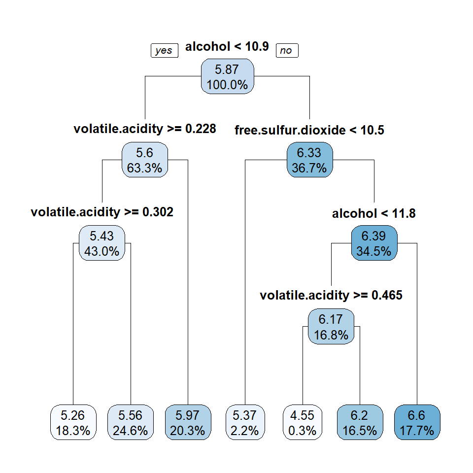

```r
rpart.plot(m.rpart, digits=3, type=1)
```

# Model evaluation

```r
p.rpart <- predict(m.rpart, wine_test)
summary(p.rpart)
```

```
##    Min. 1st Qu.  Median    Mean 3rd Qu.    Max.
##   4.545   5.563   5.971   5.893   6.202   6.597
```

```r
summary(wine_test$quality)
```

```
##    Min. 1st Qu.  Median    Mean 3rd Qu.    Max.
##   3.000   5.000   6.000   5.901   6.000   9.000
```

# News popularity

# Import the data

- Now let’s start playing with News popularity data set

```r
news <- read.csv("OnlineNewsPopularity_for_R.csv")
str(news)
```

```
## 'data.frame':    39644 obs. of  61 variables:
##  $ url                          : Factor w/ 39644 levels "http://mashable.com/2013/01/07/amazon-instant-video-browser/",..: 1 2 3 4 5 6 7 8 9 10 ...
##  $ timedelta                    : num  731 731 731 731 731 731 731 731 731 731 ...
##  $ n_tokens_title               : num  12 9 9 9 13 10 8 12 11 10 ...
##  $ n_tokens_content             : num  219 255 211 531 1072 ...
##  $ n_unique_tokens              : num  0.664 0.605 0.575 0.504 0.416 ...
##  $ n_non_stop_words             : num  1 1 1 1 1 ...
##  $ n_non_stop_unique_tokens     : num  0.815 0.792 0.664 0.666 0.541 ...
##  $ num_hrefs                    : num  4 3 3 9 19 2 21 20 2 4 ...
##  $ num_self_hrefs               : num  2 1 1 0 19 2 20 20 0 1 ...
##  $ num_imgs                     : num  1 1 1 1 20 0 20 20 0 1 ...
##  $ num_videos                   : num  0 0 0 0 0 0 0 0 0 1 ...
##  $ average_token_length         : num  4.68 4.91 4.39 4.4 4.68 ...
##  $ num_keywords                 : num  5 4 6 7 7 9 10 9 7 5 ...
##  $ data_channel_is_lifestyle    : num  0 0 0 0 0 0 1 0 0 0 ...
```

[output cut: 47 more lines]

# Import the data

- Using data as is, is not probably the best idea
- Le’s remove some of the instances

```r
newsShort <- data.frame(news$n_tokens_title, news$n_tokens_content, news$n_unique_tokens, news$n_non_stop_words, news$num_hrefs, news$num_imgs, news$num_videos, news$average_token_length, news$num_keywords, news$kw_max_max, news$global_sentiment_polarity, news$avg_positive_polarity, news$title_subjectivity, news$title_sentiment_polarity, news$abs_title_subjectivity, news$abs_title_sentiment_polarity, news$shares)

colnames(newsShort) <- c("n_tokens_title", "n_tokens_content", "n_unique_tokens", "n_non_stop_words", "num_hrefs", "num_imgs", "num_videos", "average_token_length", "num_keywords", "kw_max_max", "global_sentiment_polarity", "avg_positive_polarity", "title_subjectivity", "title_sentiment_polarity", "abs_title_subjectivity", "abs_title_sentiment_polarity", "shares")
```

# Pre-processing

- The response variable (share) is a numerical value. How can I convert it a categorical variable?
- Let’s define a treshold of 1400 share for popularity

```r
newsShort$popular = rep('na', nrow(newsShort))
for(i in 1:39644) {
     if(newsShort$shares[i] >= 1400) {
         newsShort$popular[i] = "yes"}
     else {newsShort$popular[i] = "no"}
}
newsShort$shares = newsShort$popular

newsShort$shares <- as.factor(newsShort$shares)
```

# Pre-processing

```r
set.seed(12345)
news_rand <- newsShort[order(runif(10000)), ]
```

- Start the classification analysis by set.seed to be able to recreate the analysis

```r
#Split the data into training and test datasets
news_train <- news_rand[1:9000, ]
news_test <- news_rand[9001:10000, ]
```

# Pre-processing

- We can check the proportion of data after randomization

```r
prop.table(table(news_train$shares))
```

```
##
##        no       yes
## 0.4308889 0.5691111
```

```r
prop.table(table(news_test$shares))
```

```
##
##    no   yes
## 0.414 0.586
```

# Model training

- Train the model

```r
news_model <- C5.0(news_train[-17], news_train$shares)
summary(news_model)
```

```
##
## Call:
## C5.0.default(x = news_train[-17], y = news_train$shares)
##
##
## C5.0 [Release 2.07 GPL Edition]      Tue Apr 23 14:53:56 2019
## -------------------------------
##
## Class specified by attribute `outcome'
##
## Read 9000 cases (18 attributes) from undefined.data
##
## Decision tree:
##
## popular = no: no (3878)
## popular = yes: yes (5122)
##
##
## Evaluation on training data (9000 cases):
##
##      Decision Tree
##    ----------------
##    Size      Errors
##
##       2    0( 0.0%)   <<
##
##
##     (a)   (b)    <-classified as
##    ----  ----
##    3878          (a): class no
##          5122    (b): class yes
##
##
##  Attribute usage:
##
##  100.00% popular
##
##
## Time: 0.1 secs
```

# Evaluate the model

```r
news_pred <- predict(news_model, news_test)
(p <- table(news_pred, news_test$shares))
```

```
##
## news_pred  no yes
##       no  414   0
##       yes   0 586
```

# Evaluate the model

```r
(Accuracy <- sum(diag(p))/sum(p)*100)
```

```
## [1] 100
```

- Continue with 2 more techniqueson this data set